# Lab2

Merlise Clyde

September 11, 2017

## Topics

- `termplot` Base R
- `avPlots` `library(car)`
- interactions

## Termplot Example

```r
n = 100
logx1 = rnorm(n)
x1 = exp(logx1)
x2 = abs(rnorm(n))
logy = .5 + 3*logx1 - 2*sqrt(x2) + rnorm(n)
simdat = data.frame(X1=x1, X2 = x2, Y=exp(logy))
```

## Termplot output

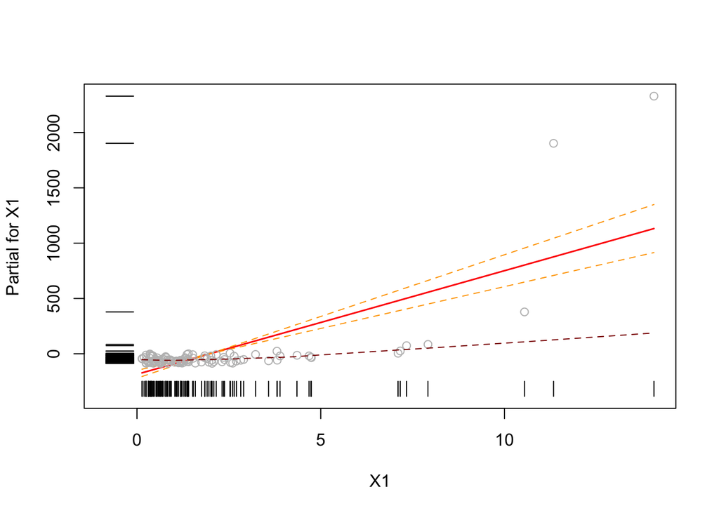

```r
termplot(lm(Y ~ X1 + X2, data=simdat), terms = "X1",
         partial.resid = T, se=T, rug=T,
         smooth = panel.smooth)
```

## Termplot output

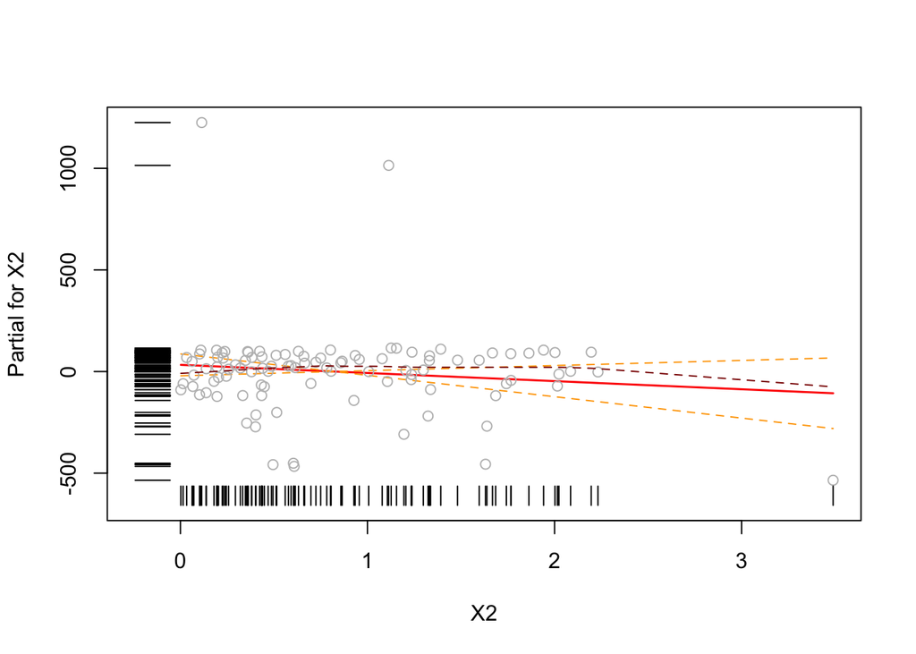

```r
termplot(lm(Y ~ X1 + X2, data=simdat), terms = "X2",
         partial.resid = T, se=T, rug=T,
         smooth = panel.smooth)
```

## termplot with transformation of Y and X1

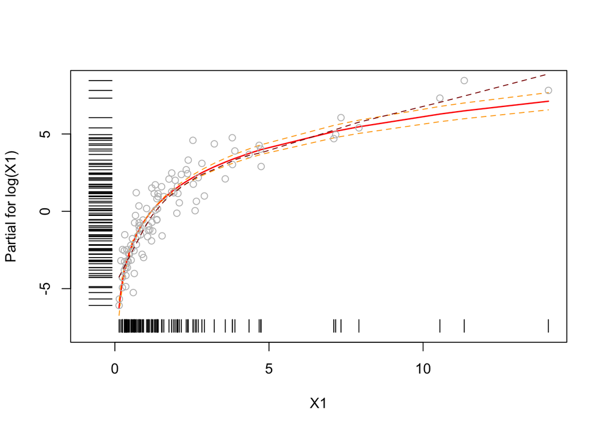

```r
termplot(lm(log(Y) ~ log(X1) + X2, data=simdat),
         terms = "log(X1)", partial.resid = T, se=T, rug=T,
         smooth = panel.smooth)
```

## termplot with transformation of Y and X1

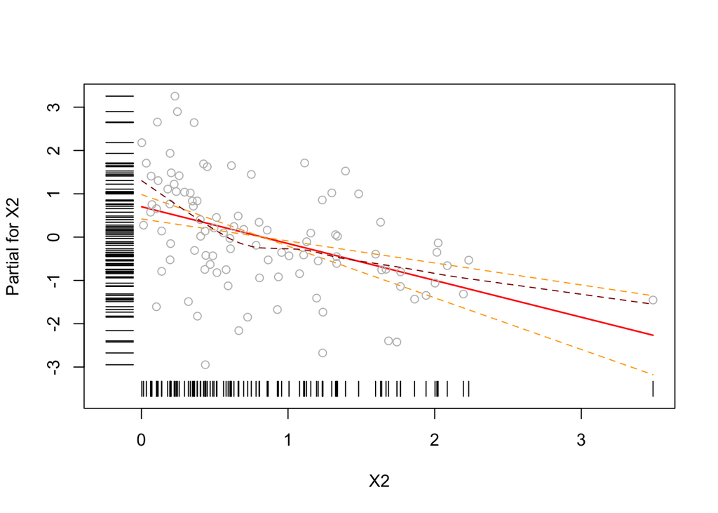

```r
termplot(lm(log(Y) ~ log(X1) + X2, data=simdat), terms = "X2",
         partial.resid = T, se=T, rug=T, smooth = panel.smooth)
```

## termplot with transformation of Y, X1, and X2

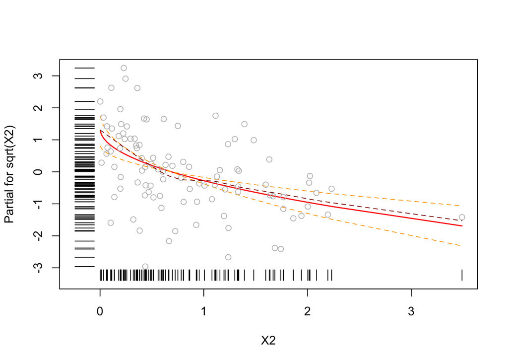

```r
termplot(lm(log(Y) ~ log(X1) + sqrt(X2), data=simdat), terms = "sqrt(X2)",
         partial.resid = T, se=T, rug=T, smooth = panel.smooth)
```

## What is in a term plot?

- x-axis is the (untransformed) variable in your dataframe $(X1, X2)$
- line is the “term” of that variable’s contribution to $f(x)$
- y-axis is partial residuals for term
- `partial.resid = T` adds the partial residuals to the plot
- `rug = T` shows location of data on axes
- `se = T` adds the SE of the term’s contribution to $f(x)$
- `smooth = panel.smooth` adds “smoothed” means to plot

## Terms

$$Y = \hat{\beta}_0 + \hat{\beta}_1 X1 + \hat{\beta}_2 X2 + e$$
Equivalent to centered model

$$Y = \bar{Y} + \hat{\beta}_1 (X1 - \bar{X1}) + \hat{\beta}_2 (X2 - \bar{X2}) + e$$
Terms are coefficient estimates times centered predictors
$$\hat{\beta}_1 (X1 - \bar{X1})$$
$$\hat{\beta}_2 (X2 - \bar{X2})$$

## Terms with transformations

$$\log(Y) = \hat{\beta}_0 + \hat{\beta}_1 \log(X1) + \hat{\beta}_2 X2 + e$$
Equivalent to centered model

$$\log(Y) = \bar{\log(Y)} + \hat{\beta}_1 (\log(X1) - \bar{\log(X1)}) + \hat{\beta}_2 (X2 - \bar{X2}) + e$$
Terms are coefficient estimates times centered “predictors”
$$\hat{\beta}_1 (\log(X1) - \bar{\log(X1)})$$

## partial residuals for a term

$$\log(Y) = \bar{\log(Y)} + \hat{\beta}_1 (\log(X1) - \bar{\log(X1)}) + \hat{\beta}_2 (X2 - \bar{X2}) + e$$

$$\log(Y) - (\bar{\log(Y)} + \hat{\beta}_1 (\log(X1) - \bar{\log(X1)})) = \hat{\beta}_2 (X2 - \bar{X2}) + e$$

- Lefthand side takes response and removes the part of the response that is explained by $X1$
- Equal to the `term` for $X2$ plus the residual $e$
- part of residual variation that is not explained by the other terms that potentially can be explained by $X2$ = partial residual for $X2$
- partial residual for X1

$$\hat{\beta}_1 (\log(X1) - \bar{\log(X1)}) + e$$
## Added Variable Plots

From `library(car)`

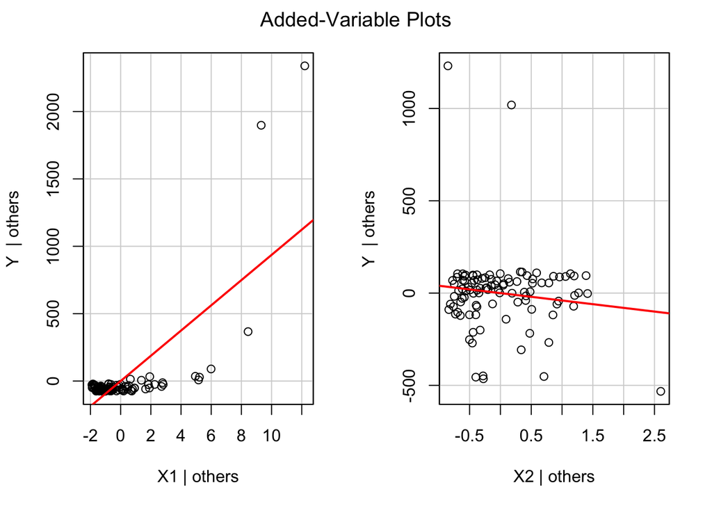

```r
library(car)
mod1 = lm(Y ~ X1 + X2, data=simdat)
avPlots(mod1)
```

In the added variable plot, on the left we regress $Y$ on $X2$ and find the residuals ($Y$ axis) and plot against the residuals from regressing $X1$ on $X2$ and plot those residuals on the $x$ axis. If after removing the effect of $X2$ on both $Y$ and $X1$, $X1$ can explain the residual variation, then we should see a relationship in the plot. The slope of the line in the added variable plot is the adjusted regression coefficient. Like termplot this can also show if the linear term in $X1$ is appropriate or perhaps there is a nonlinear relationship.

## All possible interactions

```r
lm(log(Y) ~ (log(X1) + sqrt(X2))^2, data=simdat)
```

```
##
## Call:
## lm(formula = log(Y) ~ (log(X1) + sqrt(X2))^2, data = simdat)
##
## Coefficients:
##      (Intercept)           log(X1)          sqrt(X2)  log(X1):sqrt(X2)
##           0.2853            2.6960           -1.6859            0.1832
```

Equivalent to model formula `log(X1) + sqrt(X2) + log(X1):sqrt(X2)`

## Selective proposal Interactions

- add interactions if main effects are “significant”
- think about possible reason for interaction (science)